# Global Change Biology: Primer

## What’s in a name: Evolution of terminology

- **1970s: “Inadvertent Climate Modification”**
- **1980s–1990s: “Global Warming”**
- **2000s: “Climate Change”**
- **Present: “Global Change” – includes climate change, land use, biodiversity, pollution, etc.**

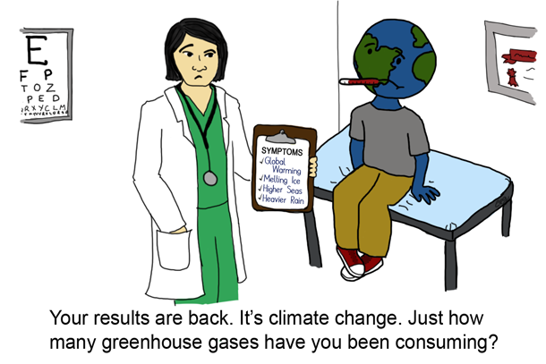

## What’s in a name: What is Global Change Biology?

- **Study of how global environmental changes affect biological systems**
- **Includes: climate change, land transformation, nutrient cycles, pollution, species introductions**
- **Focus on human-driven causes**
  - human impacts on the biosphere have ramped up at key times in our history

[figure not shown]

## What’s in a name: Anthropocene

- **Period where human activities are the dominant force shaping the Earth’s geology and ecosystems**
  - appears in scientific and social discourse
- **Denotes current geological age - YET not an officially recognized geological epoch**
  - coincides with Atomic-Age (post 1950)
  - Crawford lake (Canada) selected as ‘golden spike’
- **Proposal rejected in 2024 after 15 years of deliberation**
  - not enough data and not enough time has passes since start date

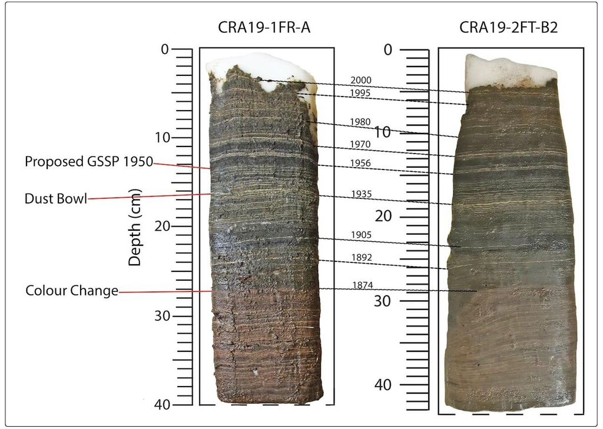

## Key drivers of global change and their consequences

- **Climate change**
- **Land transformation**
- **Disruption of biogeochemical cycles**
- **Pollution**
- **Introduction of species outside their native ranges**

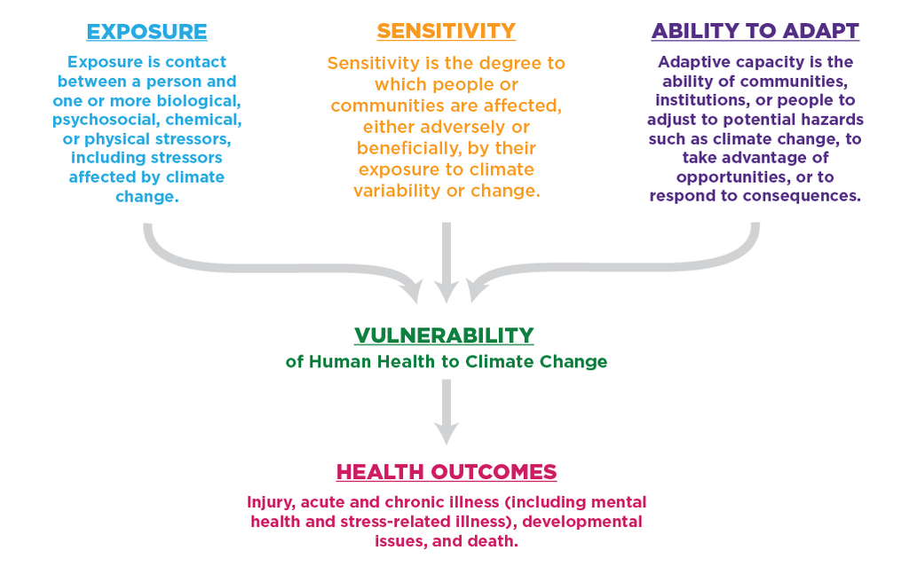

## Key drivers: Climate Change – Causes

- **Greenhouse gas emissions (GHG’s)**
  - Carbon dioxide (CO<sub>2</sub>) from industry/transportation/energy production
  - Methane (CH4) from agriculture/landfills/fossil fuels
  - Nitrous Oxide (N<sub>2</sub>0) from agriculture/industry
  - Water vapor (H<sub>2</sub>0) from evaporation
- **Deforestation - plants naturally take up (CO<sub>2</sub>)**
- **Shifts in albedo (color = reflective) from urbanization**
- **Non-human influences - Solar variability, volcanic activity, and ocean currents**

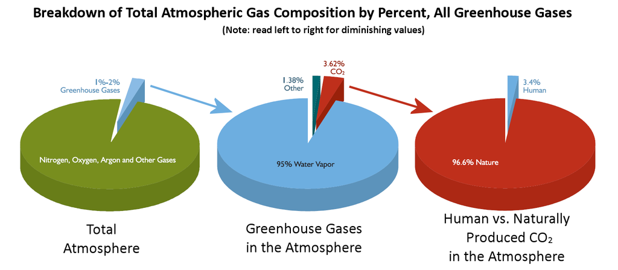

## Earth’s temperature is an energy balancing act

**Determined by the balance between incoming solar radiation, the surface, and the atmosphere**

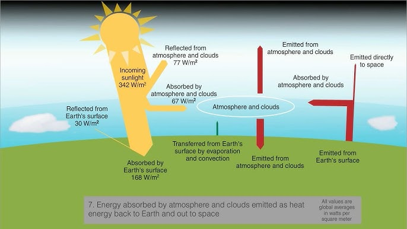

## The Greenhouse Gas Effect is a natural process

**GHG’s play a critical role in maintaining Earth’s habitable temperature. Without GHG’s, Earth would likely plunge into an ice age, as too much heat would escape back into space.**

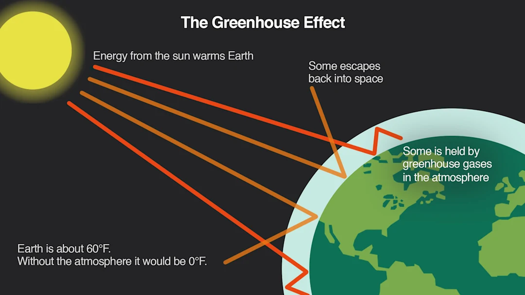

## Human have modified the existing greenhouse gas effect

[figure not shown]

## Climate Change – Effects on Natural Systems

- **Species distribution shifts**
- **Migration and breeding changes**
- **Coral bleaching, ocean acidification**
- **Extinctions**

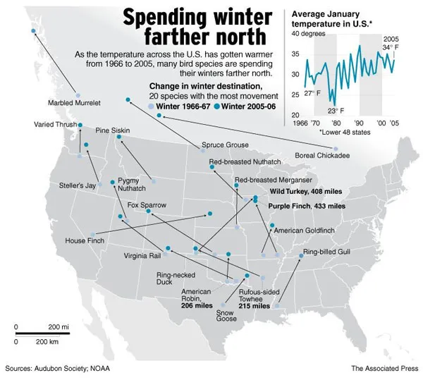

## Climate Change – Effects on Our Species

[figure not shown]

## Land Transformation by Humans is a Global Phenonmenon

- **Agriculture: Conversion of forests, grasslands, and wetlands into croplands and pastures**
- **Urbanization: Expansion of cities, roads, and infrastructure fragments natural habitats**
  - Increases impervious surfaces, disrupting water flow, urban heat islands, and pollution
- **Deforestation: Logging for timber, agriculture, and fuel**
  - removes carbon sinks, causes soil erosion, and loss of biodiversity
- **Infrastructure Development: Construction of dams, highways, and mining operations**
  - modifies/removes habitats, interrupts animal migration routes and river flows.
- **Land Drainage: Conversion of wetlands, estuaries, and mangroves for development**
  - Loss of ecosystems that buffer storms and filter pollutants.

## Land Transformation: Habitat Loss

[figure not shown]

## Land Transformation: Biodiversity

**Biodiversity hotspots intersect with the boundaries of land transformation**

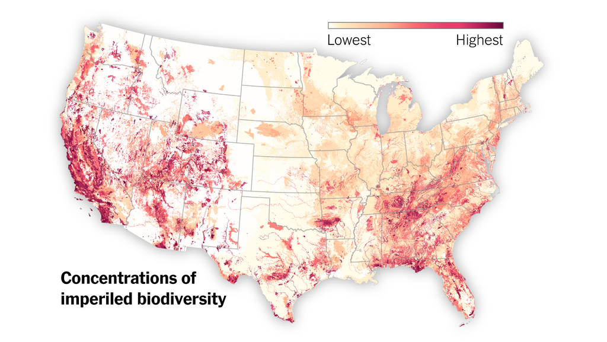

## Land Transformation: Altered Water Flows

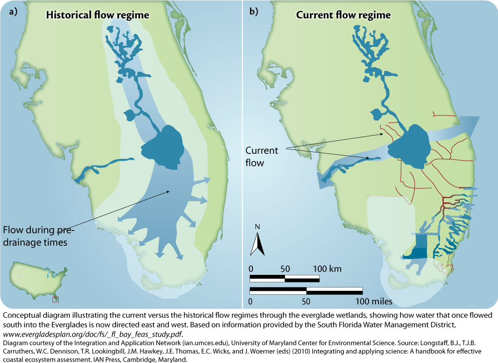

## Land Transformation: Expansion of Human-Wildland Interface

**Increases the exposure of humans and the environment to each other**

[figure not shown]

## Land Transformation: Removal of Historic Fire Regimes

**Most terrestrial ecosystems are evolved to burn through time…**

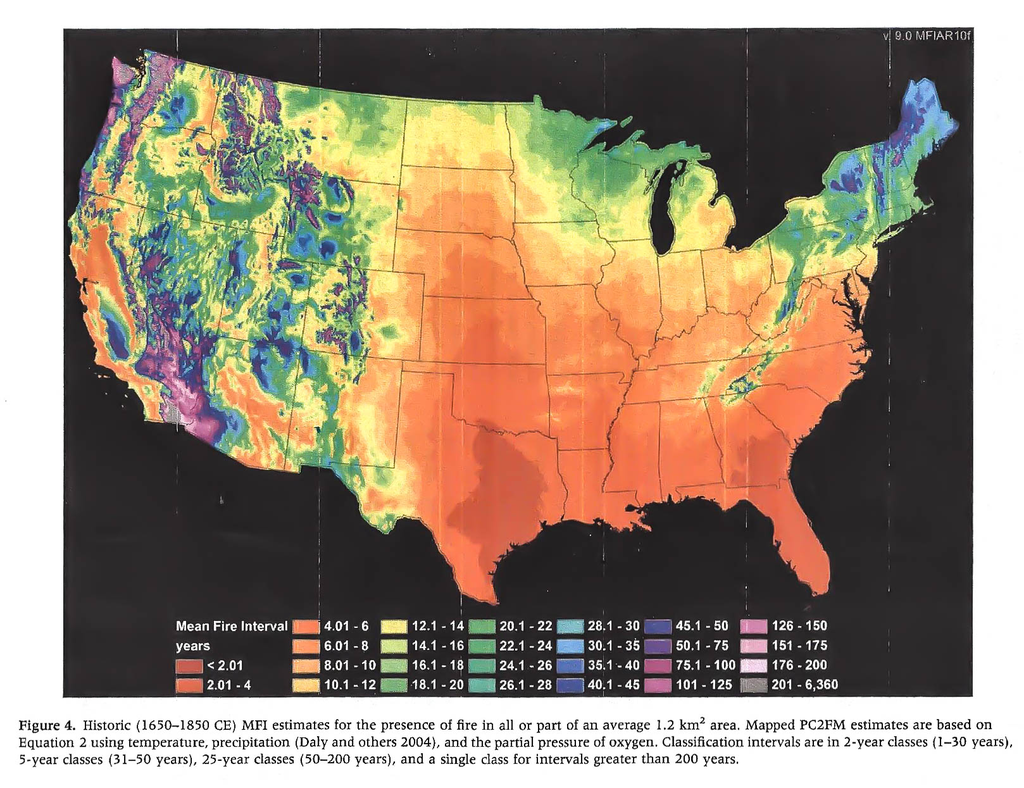

## Land Transformation: Creation of Urban Heat Islands

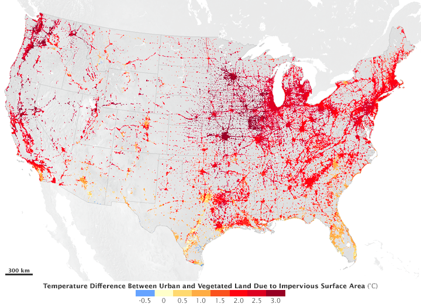

## Altered Biogeochemical Cycles – Overview

- **Biogeochemical cycle: the movement and transformation of chemical elements/compounds between living organisms, the atmosphere, and the Earth’s crust**
- **Carbon Cycle - C is main element for building organic molecules essential for life**
  - Fossil Fuel Combustion: Releases vast amounts of CO₂
  - Deforestation: Reduces the Earth’s capacity to absorb atmospheric carbon
- **Nitrogen Cycle - N is used to build molecules like proteins, nucleic acids (DNA and RNA)**
  - Synthetic Fertilizer: Adds nitrogen to soils and waterways, which escapes into aquatic ecosystems
  - Fossil Fuel Combustion: Produces greenhouse gasses, contributes to smog, and acid rain,
  - Livestock Waste: Releases greenhouse gasses
- **Phosphorus Cycle - building blocks like DNA and RNA, energy molecules, cell membranes**
  - Agricultural Runoff: Excess phosphorus from fertilizers enters rivers and lakes
  - Wastewater Discharge: Human sewage contributes to phosphorus overload in aquatic systems

## Eutrophication - Excessive N & P in Aquatic Systems

**Excessive nutrient levels lead to rapid algal growth. As these algal blooms decay, oxygen is depleted in the water, suffocating fish and other organisms**

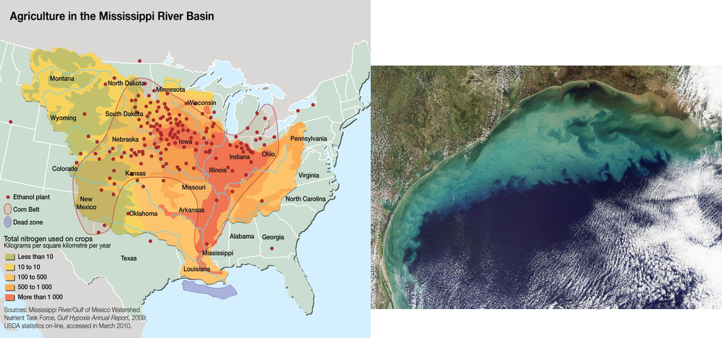

## Ocean Acidification from CO<sub>2</sub> emissions

**Oceans absorb CO<sub>2</sub>. When CO<sub>2</sub> dissolves in seawater, it an acid (carbonic acid), increasing ocean acidity. More acidification makes it harder for organisms to build/maintain shells**

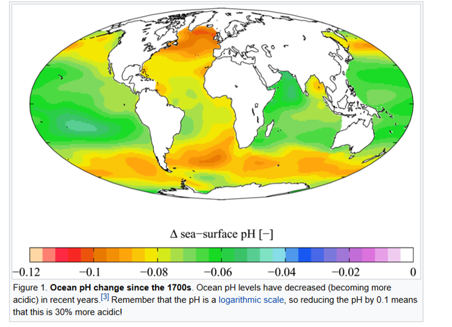

## Pollution from Humans is Vast

- **Industrial Activities (factories) emit air pollutants**
  - Chemical waste and heavy metals often contaminate soil and water
  - Plastic manufacturing also contributes to microplastic pollution
- **Vehicles release GHG’s, volatile organic compounds (VOCs), and particulate matter**
  - land and air transportation
- **Agriculture fertilizer, pesticides and herbicides contaminate soil and water**
  - harming non-target organisms
- **Residential and Urban Waste includes household chemicals, plastic, and electronic waste**
  - wastewater discharge pollutes aquatic ecosystems
- **Plastic waste, oil spills, and ballast water discharge pollute oceans and harm marine life**

## Biological Effects of Pollution

- **Reproductive decline**
- **Genetic mutations**
- **Ecosystem degradation**
- **Bioaccumulation**

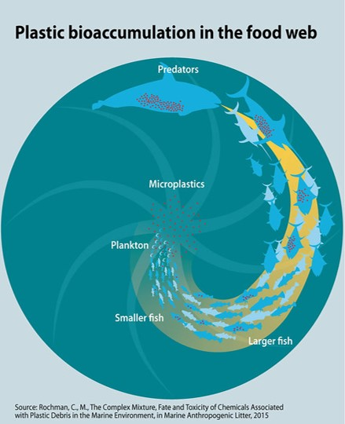

In a recent field study, microplastics were detected in all tissues—muscle, liver, digestive tract, gonads, and kidney—of 15 edible marine species, including fish, shrimp, crabs, and squid.

## Species Introductions – Why?

- **An introduced species is a species that has been brought by human activity to an area where it does not naturally occur**
- **If species becomes harmful to the environment = invasive**
- **Intentional: agriculture, pets**
  - many crop species = non-native
  - species are sometimes introduced to fight an invasive species = biocontrol
- **Unintentional: ballast water, trade**
- **Accelerated by globalization**

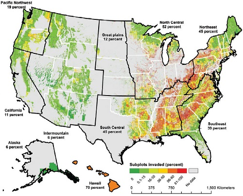

## Invasive Species – Impacts

**Invasive species often lack natural predators/diseases in new locations, allowing them to grow rapidly and outcome native species**

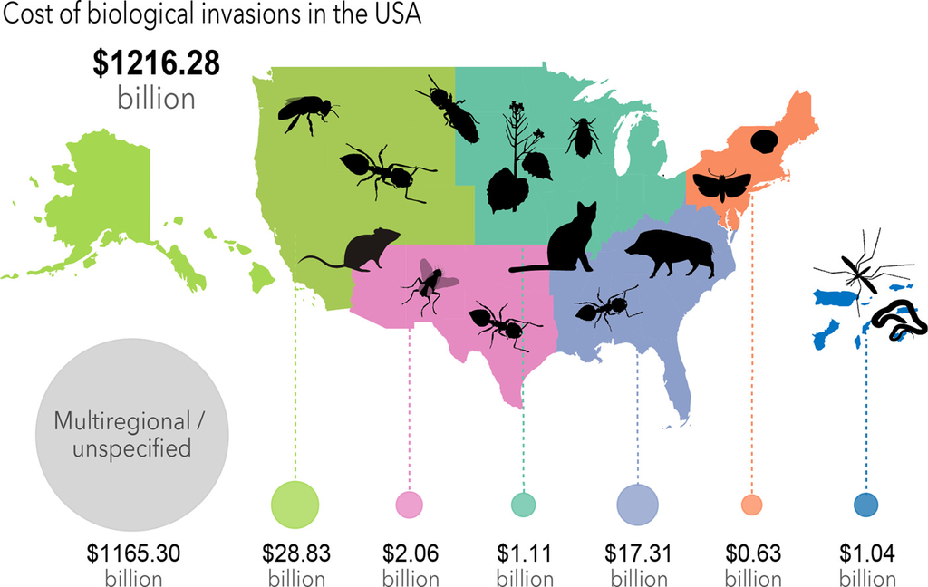

## Global Change Factors can be Interconnected

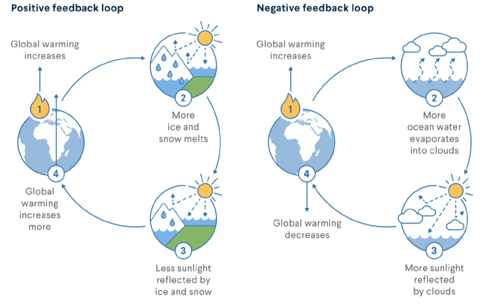

## Global Change Factors can be Interconnected – Coral Reefs

**When corals becomes stressed, the zooxanthellae (colorful algae) leave, causing coral bleaching and potentially death of the corals**

**What causes corals to be stressed?**

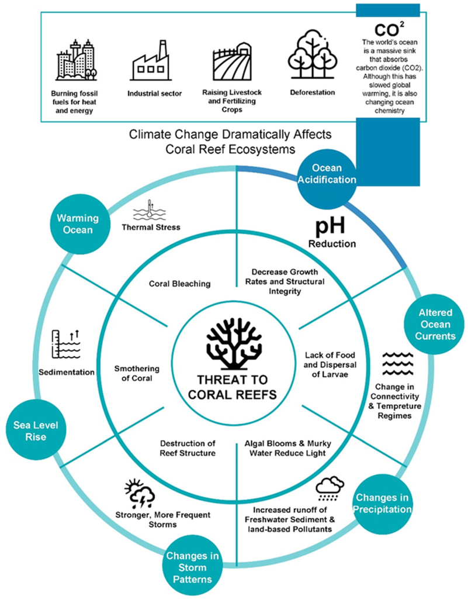